# A3: Incarceration

### Introduction

People in the United States have long noted and protested the obvious racial discrimination against people of color in law enforcement and sentencing. Black people especially make up a disproportionate amount of the people held in jail and prison. In this project I analyze the discrepancies between incarceration rates of different racial groups to quantify how biased the legal system is.

Using data from the Vera Institute, for each year, county, and racial group we calculate a “discrepancy” variable that represents how over- or under-represented that racial group is in incarcerated (jail or prison) population. This number is the rate of incarceration for that racial group divided by the rate of incarceration of the general population. We can then analyze this value to quantify how biased the legal system is for or against each racial group.

### Summary Information

We found that Black, Latinx, and Native American people are vastly over-represented in incarcerated populations. Meanwhile, Asian American and Pacific Islander people and White people are under-represented. Across all counties, where data is available, we found these mean incarceration rate discrepancies:

| Racial Group | Mean discrepancy |
| --- | --- |
| Asian American / Pacific Islander | 0.56 |
| Black | 6.953 |
| Latinx | 1.875 |
| Native American | 2.725 |
| White | 0.746 |

As we can see, Black people are incarcerated at nearly 7 times the rate they would be if sentencing was perfectly equal. Native and Latinx people are also over-represented, at 2.7 times and 1.9 times higher rates than expected. Asian American/Pacific Islander people and White people are under-represented, at 0.56 and 0.75 respectively. This is strong evidence that the American legal system is biased against certain racial groups, and biased towards others.

### The Dataset

**Who collected the data?**

This data was collected by the Vera Institute, an advocacy group that fights against “overcriminalization and mass incarceration of people of color, immigrants, and people experiencing poverty”.

**How was the data collected or generated?**

Researchers at the Vera Institute collated data from various U.S. government agencies. They primarily used data collected by the Bureau of Justice Statistics (BJS):

- Prison population and admission counts per year from 1983-2018, aggregated by county, with estimates by race and gender, from the National Corrections Reporting Program
- Jail population and admission counts, for individual facilities, from 2000-2013, from the Deaths in Custody Reporting Program
- Jail population, admission, and release counts, per year from 1985-2017, for a sample of counties, from the Annual Survey of Jails. They combine this with the DCRP data
- Jail population by gender and race, per jurisdiction and county, per 5-8 years from 1970, from the Census of Jails. They combine this with the DCRP and ASJ data

They also reference overall population data from other U.S. government agencies:

- Total population estimates, from the U.S. Census Bureau and CDC
- Urbanicity estimates, from the U.S. Census Bureau

**Why was the data collected?**

The Vera Institute collected this data to help researchers who want to analyze racial discrimination in the U.S. They also used this data themselves to create the Incarceration Trends website, a tool where people can explore trends about incarceration statistics, with a focus on racial biases. Overall, the Vera Institute uses the data to help educate people on the extent of racial bias in the legal system.

**How many observations (rows) are in your data?**

The dataset for all counties from 1990 has 91031 rows. The dataset for only Washington from 1990 has 1131 rows.

**How many features (columns) are in the data?**

Both datasets I used have 23 features.

**What, if any, ethical questions or questions of power do you need to consider when working with this data?**

This data entirely relies on statistics reported by government agencies. While these agencies may be separate from law enforcement and the legal system, they still are plagued by all of the same biases that people in power have against people of color, immigrants, and impoverished people. Malicious actors may underreport population statisics to pretend that incarceration rates are less biased than they are, and others may have reported inaccurate data because they didn’t care enough to correct it.

**What are possible limitations or problems with this data?**

A large amount of cells are missing data. For example, in the counties dataset, “black_jail_pop_rate” has NA values for 71561 out of the 153811 rows, and “aapi_prison_pop_rate” has NA values for 140615 out of the 153811 rows. We will need to choose a small subset of counties to analyze that have mostly complete or fully complete data, or filter out any NA data.

A lot of cells appear to be missing but are filled with “0” instead of NA. In Baldwin County, AL, “aapi_jail_pop_rate” goes from 406.5 to 0.0 between years 1993 and 1994, then suddenly goes back from 0.0 to 453.20 between 1998 and 1999. It’s unlikely that Baldwin County had exactly 0 Asian/Pacific Islander people in jail between 1994 and 1998.

This data only includes the 5 broad racial group distinctions used by government agencies (Asian American/Pacific Islander, Black, Latinx, Native American, White). I would prefer to have more specific distinctions, since I know our society has very different racial biases against people within these groups (for example, Indian people and Japanese people, who both are “Asian American/Pacific Islander”).

### Trends Over Time Chart

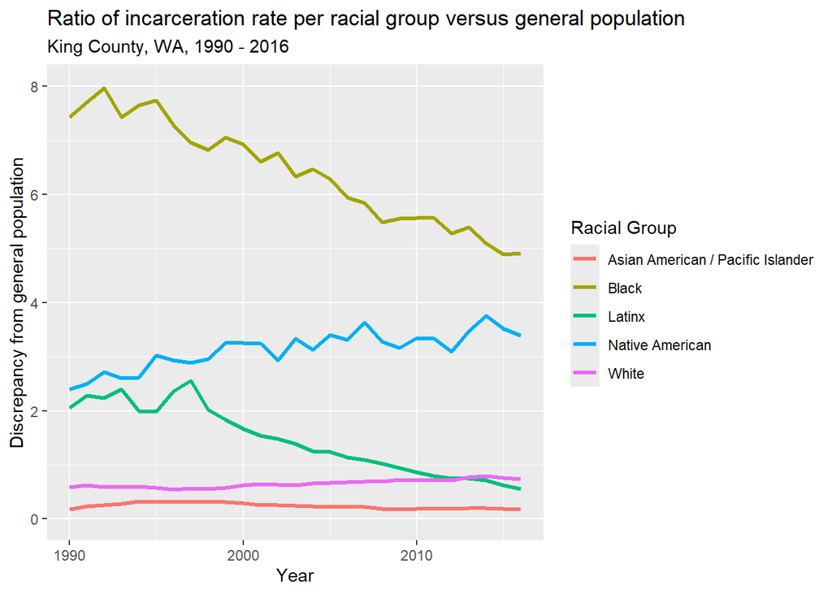

I focused in on my local area of King County to see how racial discrimination in the legal system has evolved locally over the last few decades. Each line represents, for each racial group, the discrepancy between their incarceration rate divided by the general population incarceration rate.

Before the year 2000, we see mostly the same patterns as we saw in all counties in the summary. Black, Latinx, and Native American people are over-represented in incarceration. However, after the year 2000, Latinx people have been more equally represented in incarcerated population. Around 2008, they reached the same representation as general population, and around 2013 they even became more under-represented than White people. Black people have also because less over-represented in incarceration over time. These suggest that the legal system in King County is becoming less racially biased, which is good progress. However, Native American people have increasingly become more over-represented in incarceration, and Black people remain vastly over-represented, which tells us that there is still a long way to go.

### Variable Comparison Chart

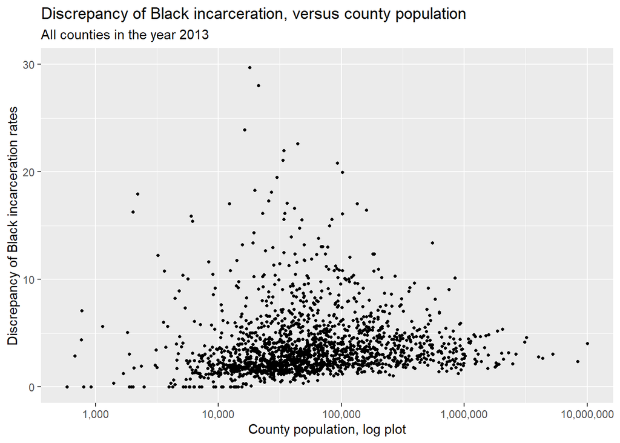

We can also see that almost all counties where Black people are over-represented in incarceration at more than 5 times general population are counties with less than 300,000 people. In addition, all counties with more than 1,000,000 people have discrepancy values of less than 6. This might suggest that rural areas (which have lower populations) are more biased against Black people than urban areas (which have higher population).

### Map

Map not implemented.